# Chemical Properties Influencing Red Wine Quality

### Sulphates by Grade

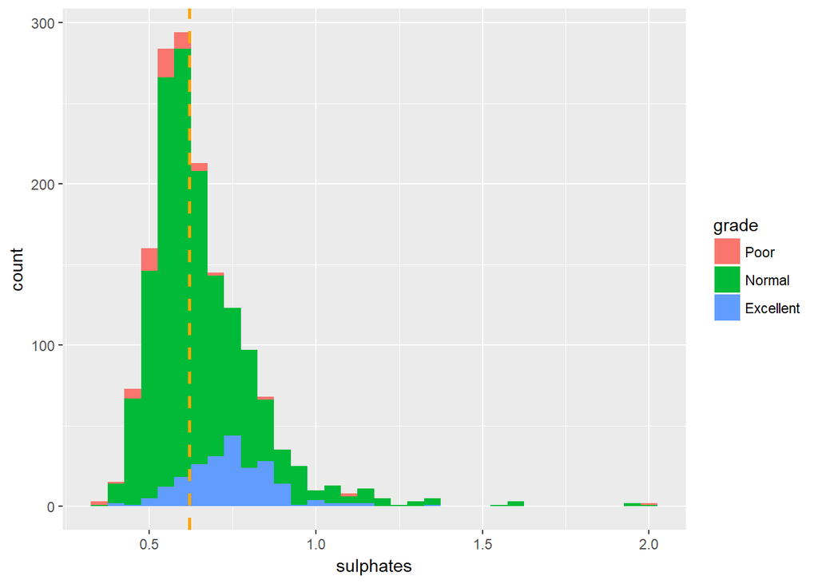

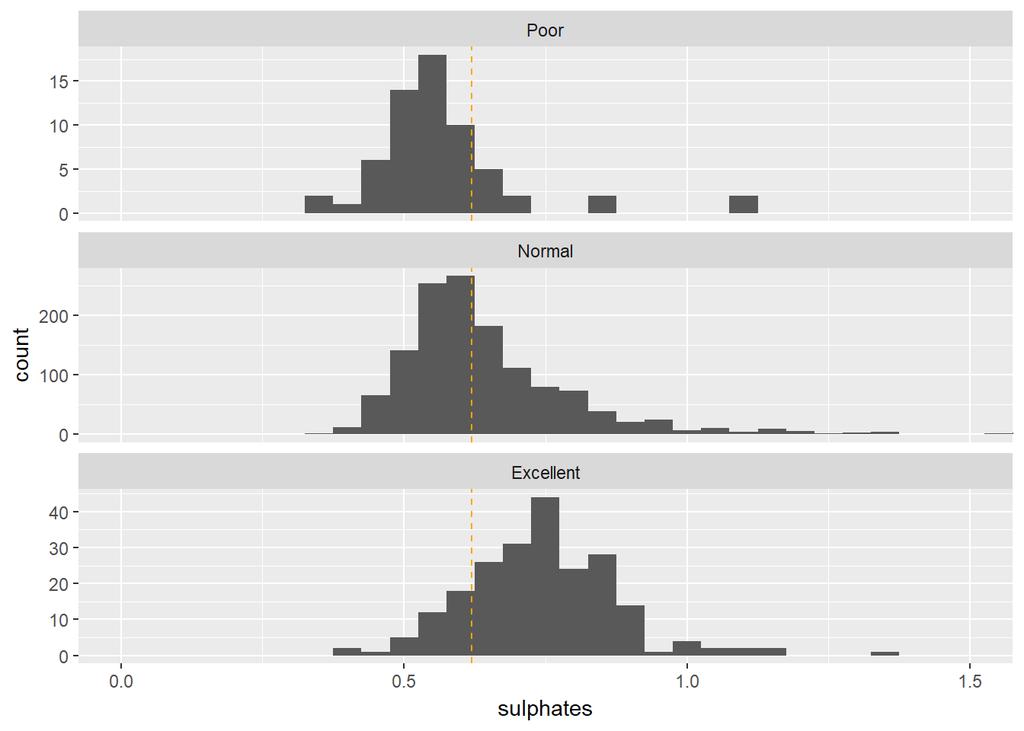

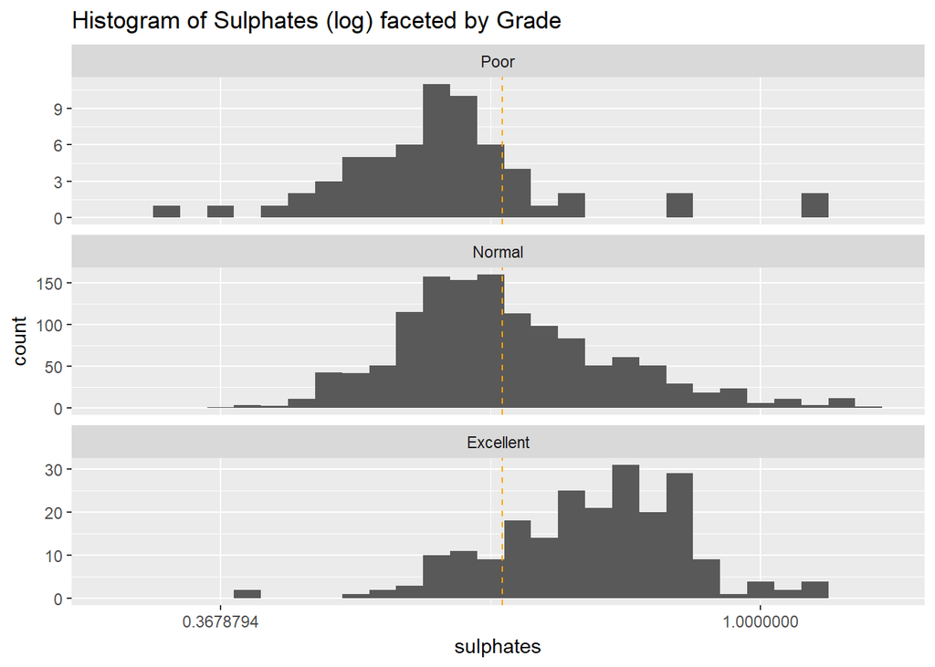

**Observation(s):**  
Excellent wines have sulphates higher than the median (dashed line) in the dataset, suggesting that sulphates play an important role in wine quality. This is supported by boxplot below.

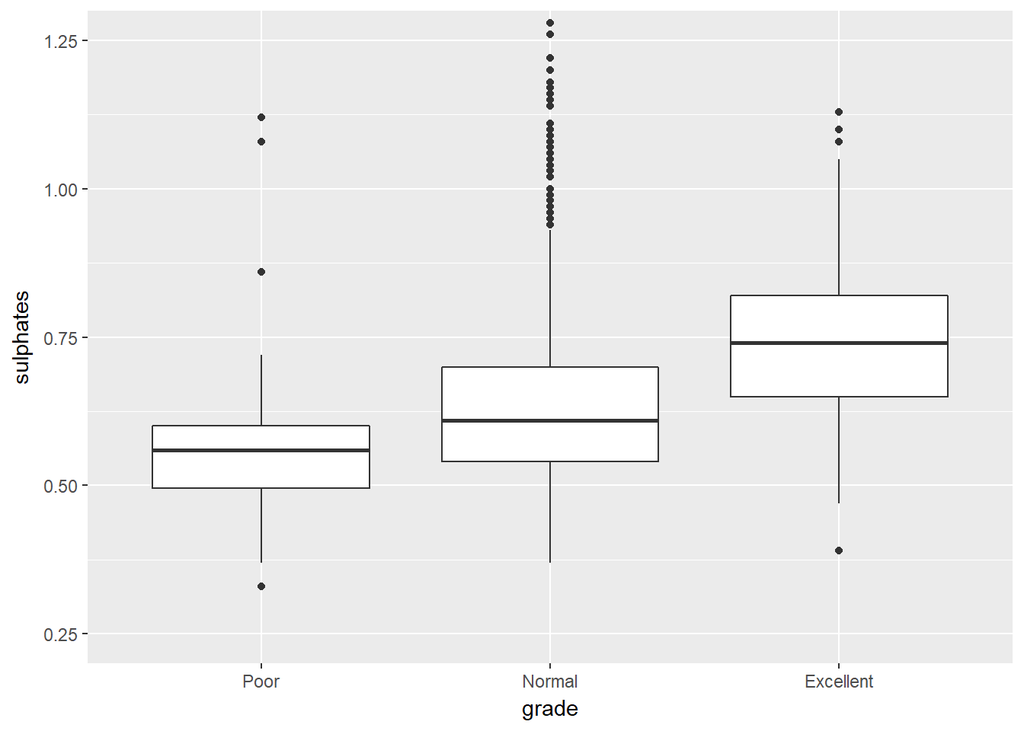

Let’s catch another glimpse of the relationship between selected chemical properties, coloured by the 2 grades of wines: Poor and Excellent.

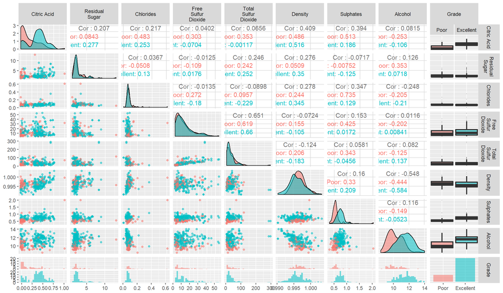

**Observation(s):**  
When Normal grade wines have been removed and the plots are coloured by grade, the multi-modal distribution of citric acid becomes apparent.

The correlation for citric acid with density increased to 0.409, while the corresponding correlation with sulphates increased to 0.39.

## Bivariate Analysis

### Talk about some of the relationships you observed in this part of the investigation. How did the feature(s) of interest vary with other features in the dataset?

I explored “grade” by “citric.acid” following the multi-modal distribution discovered in univariate plot for citric acid.

Interestingly, citric acid supposedly gives wine a fruity character. Excellent wines tend to have citric acid between 0.25 - 0.60 g/dm<sup>3</sup>, while the lower grade wines tend to have lower citric acid concentration.

However, there is a collection of wines with low citric acid concentration (0 - 0.20 g/dm<sup>3</sup>) that has been graded as Excellent. Perhaps to achieve that quality, the winemakers have infused a balance to the wines by altering the residual sugar concentration of the wine.

However, average sugar concentration of Excellent wines did not change between the range of citric acid levels of 0 - 0.6 g/dm<sup>3</sup>. Higher sugar concentration was observed for citric levels beyond 0.6 g/dm<sup>3</sup>.

On the other hand, density appeared to demonstrate tighter correlation with citric acid concentration due to the multi-modal distribution exhibited with Excellent wines.

### Did you observe any interesting relationships between the other features (not the main feature(s) of interest)?

Density is negatively correlated with alcohol (r = -0.55) and is positively correlated with residual sugar (r = 0.28). The fact that density is correlated with these two properties is mentioned in the research paper - density of wine is close to that of water depending on the percent of alcohol and sugar content.

### What was the strongest relationship you found?

The strongest relationship for citric acid is with density.

# Density over Citric Acid by Grade

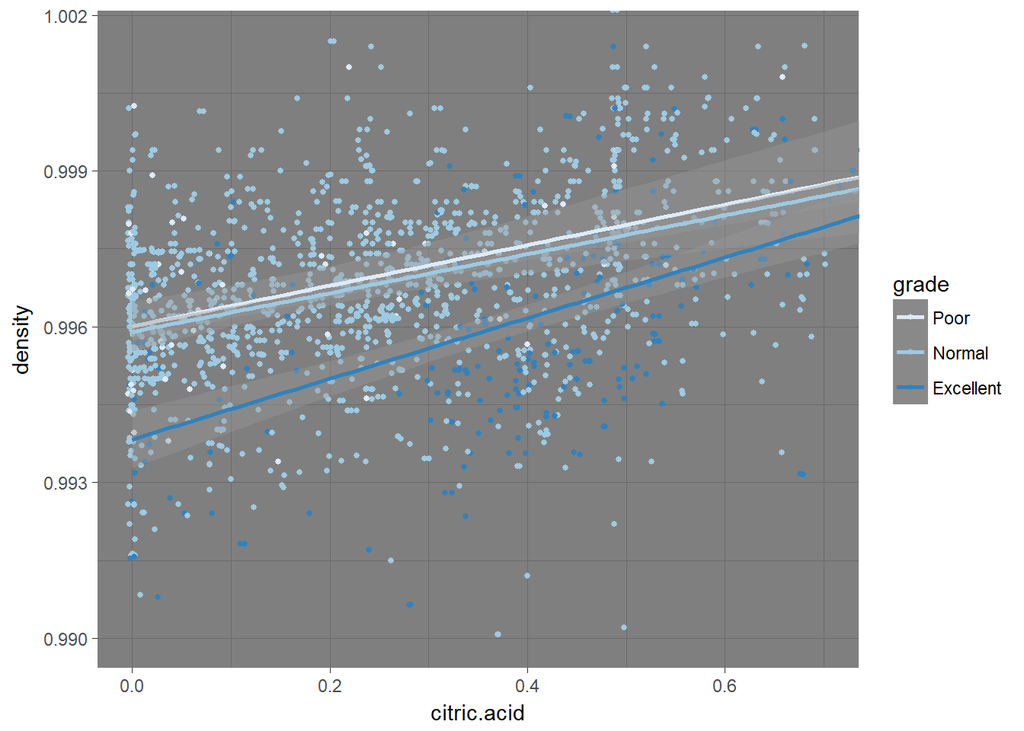

**Observation(s):**  
Excellent grade wines tend to have lower density compared to Poor and Normal wines across the range of citric acid concentration.

In the following exploration of density over citric acid, I have made a plot using a subset of Poor and Excellent grades wines. The exclusion of Normal grade wines in the plots provides a cleaner visual for comparing the influence of studied chemical properties have over wine’s quality / grade.

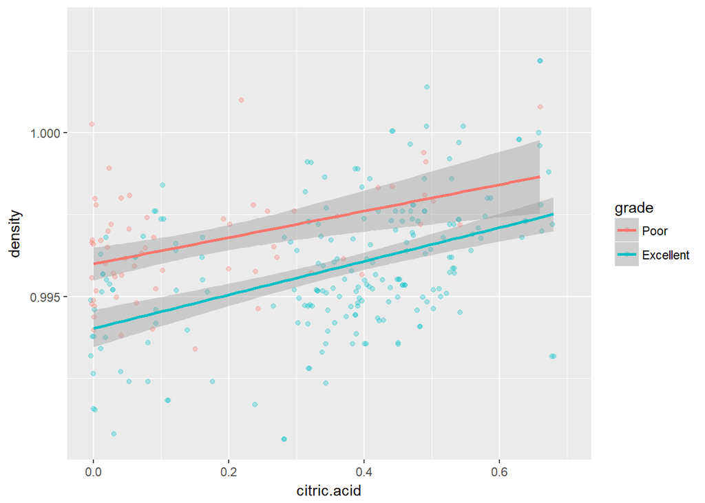

**Observation(s):**

1. Poor grade wines tend to have higher density across citric acid concentration while the Excellent grade wines tend to have lower density across the range.
2. There are 2 distinct ranges of citric acid concentration in Excellent wines; (low) 0 - 0.15 and (high) 0.3 - 0.55 g/dm<sup>3</sup>. Wines that fall between the 2 ranges tend to be of Poor grade.

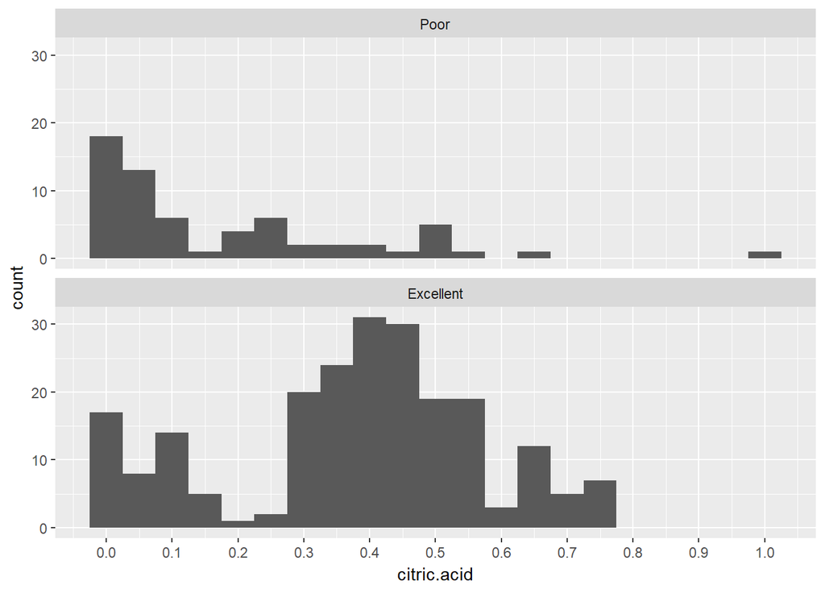

# Sulphates over Citric Acid by Grade

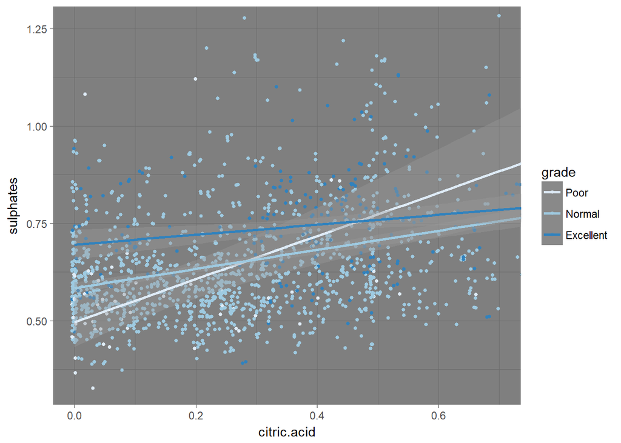

Similar to plots for density, Normal grade wines are excluded in plot below.

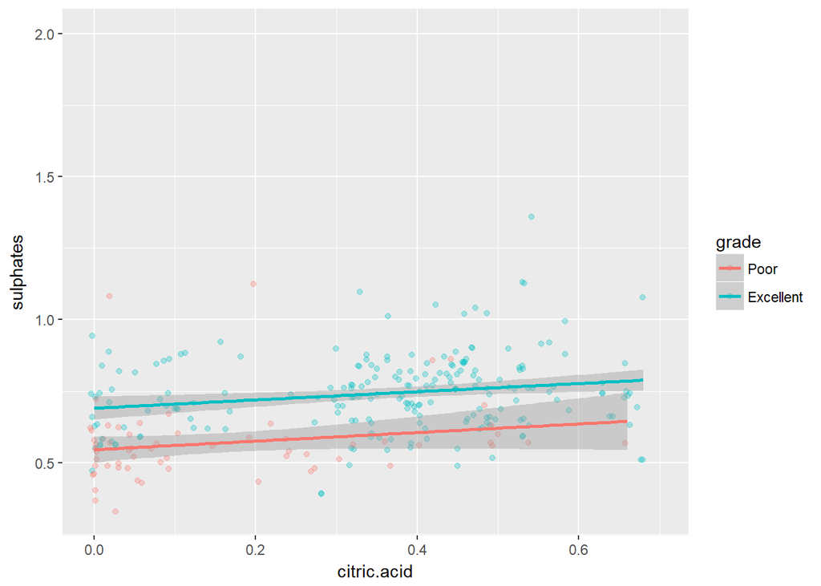

**Observation(s):**  
This plot shows a different story, in that the regression line of Poor wines do not have the same steep gradient as that previously plotted. By filtering out Normal grade wines, regression lines are confined to the more relevant limits representing the Poor and Excellent grades of wines.

The relationship between citric acid and sulphates concentration in predicting grade is inverse that of density, i.e. Excellent wines tend to have higher sulphates compared to Poor wines.

## Multivariate Analysis

### Talk about some of the relationships you observed in this part of the investigation. Were there features that strengthened each other in terms of looking at your feature(s) of interest?

1. I explored citric acid in relation to grade. I filtered away the over-represented Normal grade wine since these could be a result of  
   “safe” evaluations by wine graders.
2. Excellent wines have lower density but higher sulphates concentration compared to Poor quality wines.
3. Both density and sulphates display positive correlation with citric acid, albeit with moderate (density-citric) and low strength (sulphates-citric).

### Were there any interesting or surprising interactions between features?

The 2 ranges of citric acid concentration where wines were graded Excellent was interesting. This suggests that there are 2 distinct preferences for wine when it comes to “fruitiness”.

## Final Plots and Summary

### Plot One

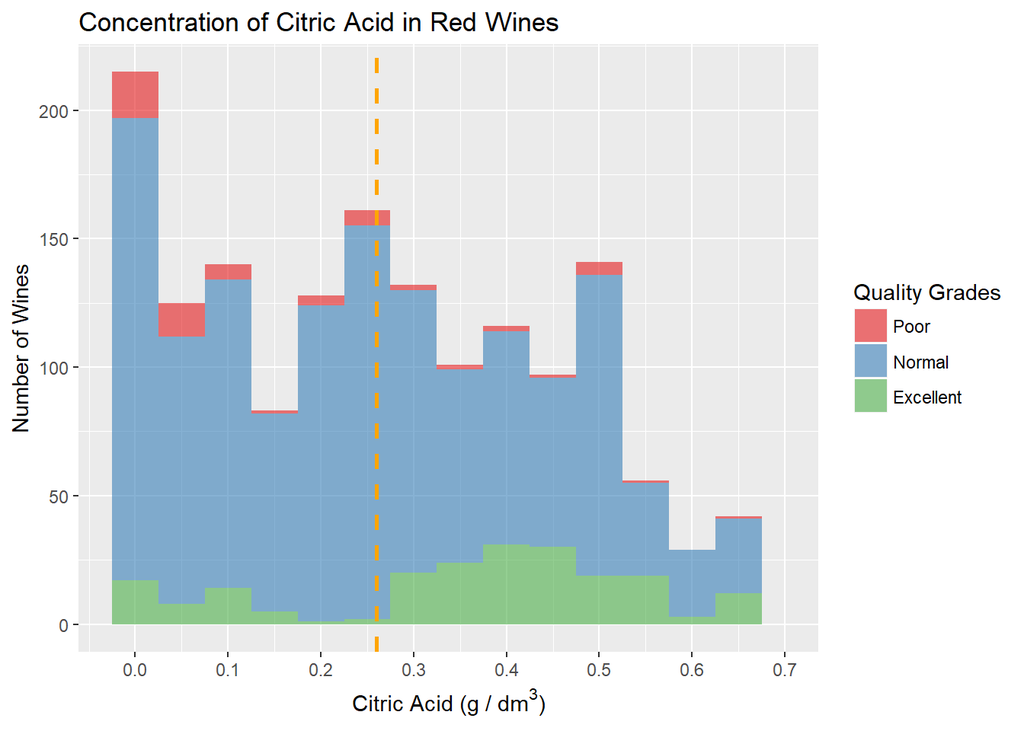

### Description One

The histogram plot of citric acid concentration in red wines illustrates differed from histogram plots of other chemical properties in that it has a multi-modal distribution.

This plot prompted me to explore the relation of citric acid against wine quality (grade) further.

The multi-modal distribution is more apparent when the plot is coloured by the grade of red wines; noticebly, Excellent grade wines have bi-modal distribution around 2 distinct citric acid concentration.

I was curious to discover what would make red wines with low citric acid concentration just as desirable as those with higher citric acid concentration?

### Plot Two

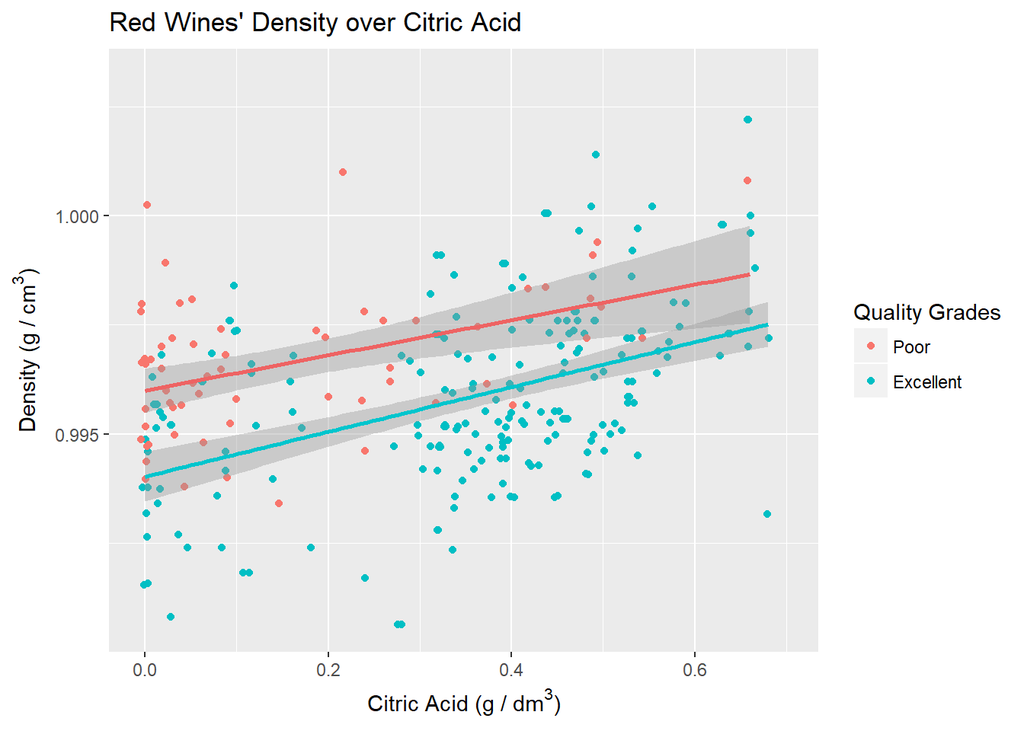

### Description Two

This plot of Density to Citric Acid shows that Excellent grade wines tend to cluster around 2 concentrations of Citric Acid:  
1. Low concentration of 0 - 0.15 g / dm<sup>3</sup>  
2. High concentration of 0.30 - 0.55 g / dm<sup>3</sup>

However, throughout the range of Citric Acid concentration, Density of Excellent wines tends to be lower than that of Poor wines.

### Plot Three

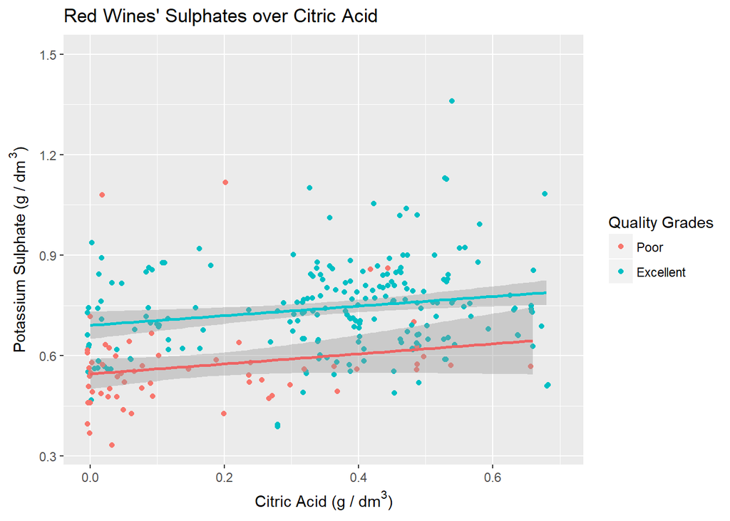

### Description Three

The relationship between Sulphates and Citric Acid concentration for the 2 grades of wine is the inverse of that between Density and Citric Acid. Here, Excellent wines tend to have higher Sulphates concentration across the range of Citric Acid compared to Poor wines.

## Reflection

I set out to look for chemical properties that may contribute to red wine’s quality, using a data set comprising of 1,599 wine entries with 11 chemical properties.

The quality rating of wines ranged from 3 - 8. Wines with quality ratings of 5 & 6 dominated the set of wine being studied. I decided that it would be easier to observe relationships if the range of quality score were grouped into 3 broader grades of Poor, Normal and Excellent.

Having looked at univariate plots of each property, I explored citric acid concentration due to its interesting multi-modal distribution.

By plotting citric acid coloured by the grade of wine, I observed that Excellent wine has bi-modal distribution centered over low (0 - 0.15 g/dm<sup>3</sup>) or high (0.30 - 0.55 g / dm<sup>3</sup>) citric acid concentration. I wanted to find out if there were other chemical properties that would make up for the different citric acid concentrations in order to yield high scoring wines. I was expecting to see that Excellent wines with low citric acid concentration might have notably different concentration of other chemical properties compared to their high citric acid counterparts.

I studied the relationship of density and sulphates with citric acid since a scatter plot matrix indicated correlations exist between these properties.

Density and sulphates in wines did not demonstrate trends that would compensate for low- or high citric acid concentrations in attaining Poor or Excellent grades. What was observed was that across the range of citric acid:

1. Excellent wines have lower density compared to Poor wines;
2. Excellent wines have higher sulphates compared to Poor wines; and,
3. Both density and sulphates have positive correlation with citric acid in Poor as well as Excellent wines.

Citric acid is known to give wine its fruity taste. I did not observe any trends in 2 other chemical properties (i.e. density and sulphates) that compensated for the low concentration of citric acid in making a wine Excellent as its high citric acid counterpart.

It appears that consumers’ personal preference for red wines with either low or high citric acid concentration (non-fruity or fruity) wines allows red wines with low citric acid to score as Excellent.

Aiding with the quality of wine are the density and sulphates concentration - Excellent wines have lower density but higher sulphates compared to Poor wines.

### Challenges & Future Work Possibilities

Trying to spot patterns in the data set was a challenge since the majority (over 82%) of wines was scored in the “Normal” grade, leaving less than 20% of wines to study for patterns contributing to Excellent and comparing that to Poor wines.

For instance, it was difficult to discern if citric acid levels in red wine which influence the wine’s fruitiness were range bound between 0 - 0.2 g/dm<sup>3</sup> and 0.25 - 0.60 g/dm<sup>3</sup>, or might also include a 3rd range of 0.60 - 0.80 g/dm<sup>3</sup>.

For future work, I expect that performing the analysis on a data set with larger representations of Poor and Excellent wines will yield more compelling observations.